# Risk Factor Analysis

## Outcome Variable

**Outcome Variable:** y_rate_len

## Predictor Variables

**Intervention Variable:** exclfeed6

**Adjustment Set:**

unadjusted

## Stratifying Variables

The analysis was stratified on these variable(s):

- agecat
- studyid
- country

## Data Summary

| agecat | studyid | country | exclfeed6 | n_cell | n |
| --- | --- | --- | --- | --- | --- |
| 0-3 months | ki0047075b-MAL-ED | BANGLADESH | 0 | 177 | 233 |
| 0-3 months | ki0047075b-MAL-ED | BANGLADESH | 1 | 56 | 233 |
| 0-3 months | ki0047075b-MAL-ED | BRAZIL | 0 | 163 | 175 |
| 0-3 months | ki0047075b-MAL-ED | BRAZIL | 1 | 12 | 175 |
| 0-3 months | ki0047075b-MAL-ED | INDIA | 0 | 188 | 193 |
| 0-3 months | ki0047075b-MAL-ED | INDIA | 1 | 5 | 193 |
| 0-3 months | ki0047075b-MAL-ED | NEPAL | 0 | 162 | 173 |
| 0-3 months | ki0047075b-MAL-ED | NEPAL | 1 | 11 | 173 |
| 0-3 months | ki0047075b-MAL-ED | PERU | 0 | 248 | 258 |
| 0-3 months | ki0047075b-MAL-ED | PERU | 1 | 10 | 258 |
| 0-3 months | ki0047075b-MAL-ED | SOUTH AFRICA | 0 | 209 | 209 |
| 0-3 months | ki0047075b-MAL-ED | SOUTH AFRICA | 1 | 0 | 209 |
| 0-3 months | ki0047075b-MAL-ED | TANZANIA, UNITED REPUBLIC OF | 0 | 223 | 224 |
| 0-3 months | ki0047075b-MAL-ED | TANZANIA, UNITED REPUBLIC OF | 1 | 1 | 224 |
| 0-3 months | ki1000108-CMC-V-BCS-2002 | INDIA | 0 | 0 | 6 |
| 0-3 months | ki1000108-CMC-V-BCS-2002 | INDIA | 1 | 6 | 6 |
| 0-3 months | ki1000108-IRC | INDIA | 0 | 14 | 14 |
| 0-3 months | ki1000108-IRC | INDIA | 1 | 0 | 14 |
| 0-3 months | ki1000109-EE | PAKISTAN | 0 | 260 | 594 |
| 0-3 months | ki1000109-EE | PAKISTAN | 1 | 334 | 594 |
| 0-3 months | ki1000304b-SAS-CompFeed | INDIA | 0 | 19 | 398 |
| 0-3 months | ki1000304b-SAS-CompFeed | INDIA | 1 | 379 | 398 |
| 0-3 months | ki1017093b-PROVIDE | BANGLADESH | 0 | 467 | 634 |
| 0-3 months | ki1017093b-PROVIDE | BANGLADESH | 1 | 167 | 634 |
| 0-3 months | ki1101329-Keneba | GAMBIA | 0 | 816 | 1207 |
| 0-3 months | ki1101329-Keneba | GAMBIA | 1 | 391 | 1207 |
| 0-3 months | kiGH5241-JiVitA-3 | BANGLADESH | 0 | 8734 | 40078 |
| 0-3 months | kiGH5241-JiVitA-3 | BANGLADESH | 1 | 31344 | 40078 |
| 0-3 months | kiGH5241-JiVitA-4 | BANGLADESH | 0 | 592 | 3610 |
| 0-3 months | kiGH5241-JiVitA-4 | BANGLADESH | 1 | 3018 | 3610 |

[output cut: 98 more lines]

The following strata were considered:

- agecat: 0-3 months, studyid: ki0047075b-MAL-ED, country: BANGLADESH
- agecat: 0-3 months, studyid: ki0047075b-MAL-ED, country: BRAZIL
- agecat: 0-3 months, studyid: ki0047075b-MAL-ED, country: INDIA
- agecat: 0-3 months, studyid: ki0047075b-MAL-ED, country: NEPAL
- agecat: 0-3 months, studyid: ki0047075b-MAL-ED, country: PERU
- agecat: 0-3 months, studyid: ki0047075b-MAL-ED, country: SOUTH AFRICA
- agecat: 0-3 months, studyid: ki0047075b-MAL-ED, country: TANZANIA, UNITED REPUBLIC OF
- agecat: 0-3 months, studyid: ki1000108-CMC-V-BCS-2002, country: INDIA
- agecat: 0-3 months, studyid: ki1000108-IRC, country: INDIA
- agecat: 0-3 months, studyid: ki1000109-EE, country: PAKISTAN
- agecat: 0-3 months, studyid: ki1000304b-SAS-CompFeed, country: INDIA
- agecat: 0-3 months, studyid: ki1017093b-PROVIDE, country: BANGLADESH
- agecat: 0-3 months, studyid: ki1101329-Keneba, country: GAMBIA
- agecat: 0-3 months, studyid: kiGH5241-JiVitA-3, country: BANGLADESH
- agecat: 0-3 months, studyid: kiGH5241-JiVitA-4, country: BANGLADESH
- agecat: 12-24 months, studyid: ki0047075b-MAL-ED, country: BANGLADESH
- agecat: 12-24 months, studyid: ki0047075b-MAL-ED, country: BRAZIL
- agecat: 12-24 months, studyid: ki0047075b-MAL-ED, country: INDIA
- agecat: 12-24 months, studyid: ki0047075b-MAL-ED, country: NEPAL
- agecat: 12-24 months, studyid: ki0047075b-MAL-ED, country: PERU
- agecat: 12-24 months, studyid: ki0047075b-MAL-ED, country: SOUTH AFRICA
- agecat: 12-24 months, studyid: ki0047075b-MAL-ED, country: TANZANIA, UNITED REPUBLIC OF
- agecat: 12-24 months, studyid: ki1000108-CMC-V-BCS-2002, country: INDIA
- agecat: 12-24 months, studyid: ki1000108-IRC, country: INDIA
- agecat: 12-24 months, studyid: ki1017093b-PROVIDE, country: BANGLADESH
- agecat: 12-24 months, studyid: ki1101329-Keneba, country: GAMBIA
- agecat: 12-24 months, studyid: ki1113344-GMS-Nepal, country: NEPAL
- agecat: 12-24 months, studyid: ki1148112-LCNI-5, country: MALAWI
- agecat: 12-24 months, studyid: kiGH5241-JiVitA-3, country: BANGLADESH
- agecat: 12-24 months, studyid: kiGH5241-JiVitA-4, country: BANGLADESH
- agecat: 3-6 months, studyid: ki0047075b-MAL-ED, country: BANGLADESH
- agecat: 3-6 months, studyid: ki0047075b-MAL-ED, country: BRAZIL
- agecat: 3-6 months, studyid: ki0047075b-MAL-ED, country: INDIA
- agecat: 3-6 months, studyid: ki0047075b-MAL-ED, country: NEPAL
- agecat: 3-6 months, studyid: ki0047075b-MAL-ED, country: PERU
- agecat: 3-6 months, studyid: ki0047075b-MAL-ED, country: SOUTH AFRICA
- agecat: 3-6 months, studyid: ki0047075b-MAL-ED, country: TANZANIA, UNITED REPUBLIC OF
- agecat: 3-6 months, studyid: ki1000108-CMC-V-BCS-2002, country: INDIA
- agecat: 3-6 months, studyid: ki1000108-IRC, country: INDIA
- agecat: 3-6 months, studyid: ki1000109-EE, country: PAKISTAN
- agecat: 3-6 months, studyid: ki1000304b-SAS-CompFeed, country: INDIA
- agecat: 3-6 months, studyid: ki1017093b-PROVIDE, country: BANGLADESH
- agecat: 3-6 months, studyid: ki1101329-Keneba, country: GAMBIA
- agecat: 3-6 months, studyid: ki1113344-GMS-Nepal, country: NEPAL
- agecat: 3-6 months, studyid: kiGH5241-JiVitA-3, country: BANGLADESH
- agecat: 3-6 months, studyid: kiGH5241-JiVitA-4, country: BANGLADESH
- agecat: 6-12 months, studyid: ki0047075b-MAL-ED, country: BANGLADESH
- agecat: 6-12 months, studyid: ki0047075b-MAL-ED, country: BRAZIL
- agecat: 6-12 months, studyid: ki0047075b-MAL-ED, country: INDIA
- agecat: 6-12 months, studyid: ki0047075b-MAL-ED, country: NEPAL
- agecat: 6-12 months, studyid: ki0047075b-MAL-ED, country: PERU
- agecat: 6-12 months, studyid: ki0047075b-MAL-ED, country: SOUTH AFRICA
- agecat: 6-12 months, studyid: ki0047075b-MAL-ED, country: TANZANIA, UNITED REPUBLIC OF
- agecat: 6-12 months, studyid: ki1000108-CMC-V-BCS-2002, country: INDIA
- agecat: 6-12 months, studyid: ki1000108-IRC, country: INDIA
- agecat: 6-12 months, studyid: ki1000109-EE, country: PAKISTAN
- agecat: 6-12 months, studyid: ki1000304b-SAS-CompFeed, country: INDIA
- agecat: 6-12 months, studyid: ki1000304b-SAS-FoodSuppl, country: INDIA
- agecat: 6-12 months, studyid: ki1017093b-PROVIDE, country: BANGLADESH
- agecat: 6-12 months, studyid: ki1101329-Keneba, country: GAMBIA
- agecat: 6-12 months, studyid: ki1113344-GMS-Nepal, country: NEPAL
- agecat: 6-12 months, studyid: ki1148112-LCNI-5, country: MALAWI
- agecat: 6-12 months, studyid: kiGH5241-JiVitA-3, country: BANGLADESH
- agecat: 6-12 months, studyid: kiGH5241-JiVitA-4, country: BANGLADESH

### Dropped Strata

Some strata were dropped due to rare outcomes:

- agecat: 0-3 months, studyid: ki0047075b-MAL-ED, country: SOUTH AFRICA
- agecat: 0-3 months, studyid: ki0047075b-MAL-ED, country: TANZANIA, UNITED REPUBLIC OF
- agecat: 0-3 months, studyid: ki1000108-CMC-V-BCS-2002, country: INDIA
- agecat: 0-3 months, studyid: ki1000108-IRC, country: INDIA
- agecat: 3-6 months, studyid: ki0047075b-MAL-ED, country: SOUTH AFRICA
- agecat: 3-6 months, studyid: ki0047075b-MAL-ED, country: TANZANIA, UNITED REPUBLIC OF
- agecat: 3-6 months, studyid: ki1000108-CMC-V-BCS-2002, country: INDIA
- agecat: 3-6 months, studyid: ki1000108-IRC, country: INDIA
- agecat: 6-12 months, studyid: ki0047075b-MAL-ED, country: SOUTH AFRICA
- agecat: 6-12 months, studyid: ki0047075b-MAL-ED, country: TANZANIA, UNITED REPUBLIC OF
- agecat: 6-12 months, studyid: ki1000108-CMC-V-BCS-2002, country: INDIA
- agecat: 6-12 months, studyid: ki1000108-IRC, country: INDIA
- agecat: 6-12 months, studyid: ki1000109-EE, country: PAKISTAN
- agecat: 6-12 months, studyid: ki1000304b-SAS-FoodSuppl, country: INDIA
- agecat: 12-24 months, studyid: ki0047075b-MAL-ED, country: SOUTH AFRICA
- agecat: 12-24 months, studyid: ki0047075b-MAL-ED, country: TANZANIA, UNITED REPUBLIC OF
- agecat: 12-24 months, studyid: ki1000108-CMC-V-BCS-2002, country: INDIA
- agecat: 12-24 months, studyid: ki1000108-IRC, country: INDIA

## Methods Detail

We’re interested in the causal parameters $E[Y_a]$ for all values of $a \in \mathcal{A}$. These parameters represent the mean outcome if, possibly contrary to fact, we intervened to set all units to have $A=a$. Under the randomization and positivity assumptions, these are identified by the statistical parameters $\psi_a=E_W[E_{Y|A,W}(Y|A=a,W)]$. In addition, we’re interested in the mean of $Y$, $E[Y]$ under no intervention (the observed mean). We will estimate these parameters by using SuperLearner to fit the relevant likelihood factors – $E_{Y|A,W}(Y|A=a,W)$ and $p(A=a|W)$, and then updating our likelihood fit using a joint TMLE.

For unadjusted analyses ($W=\{\}$), initial likelihoods were estimated using Lrnr_glm to estimate the simple $E(Y|A)$ and Lrnr_mean to estimate $p(A)$. For adjusted analyses, a small library containing Lrnr_glmnet, Lrnr_xgboost, and Lrnr_mean was used.

Having estimated these parameters, we will then use the delta method to estimate relative risks and attributable risks relative to a prespecified baseline level of $A$.

# Results Detail

## Results Plots

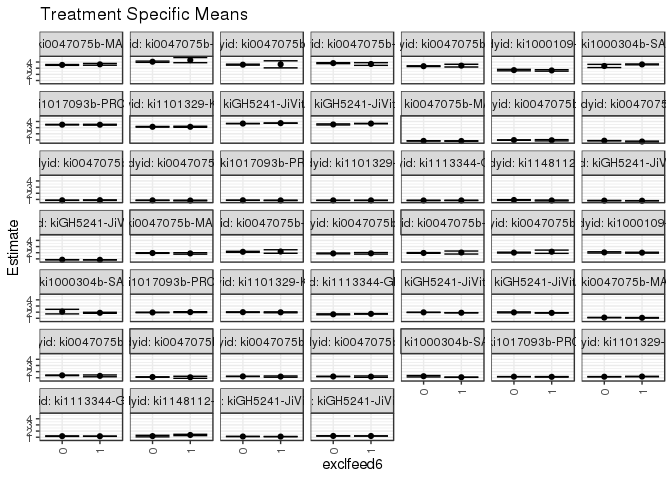

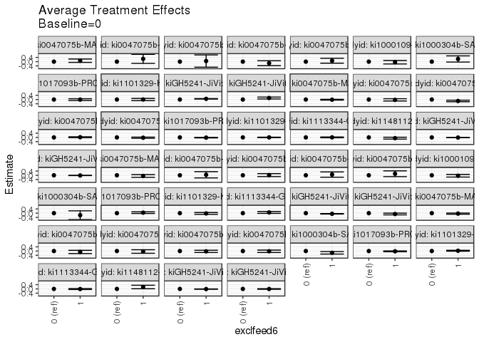

## Results Table

### Parameter: TSM

| agecat | studyid | country | intervention_level | baseline_level | estimate | ci_lower | ci_upper |
| --- | --- | --- | --- | --- | --- | --- | --- |
| 0-3 months | ki0047075b-MAL-ED | BANGLADESH | 0 | NA | 3.5338446 | 3.4646737 | 3.6030156 |
| 0-3 months | ki0047075b-MAL-ED | BANGLADESH | 1 | NA | 3.6234668 | 3.4780650 | 3.7688686 |
| 0-3 months | ki0047075b-MAL-ED | BRAZIL | 0 | NA | 4.0508766 | 3.9458371 | 4.1559162 |
| 0-3 months | ki0047075b-MAL-ED | BRAZIL | 1 | NA | 4.3135000 | 3.8980732 | 4.7289269 |
| 0-3 months | ki0047075b-MAL-ED | INDIA | 0 | NA | 3.5715005 | 3.4937661 | 3.6492348 |
| 0-3 months | ki0047075b-MAL-ED | INDIA | 1 | NA | 3.6269354 | 3.0523559 | 4.2015148 |
| 0-3 months | ki0047075b-MAL-ED | NEPAL | 0 | NA | 3.8263417 | 3.7459117 | 3.9067717 |
| 0-3 months | ki0047075b-MAL-ED | NEPAL | 1 | NA | 3.6805854 | 3.4626981 | 3.8984727 |
| 0-3 months | ki0047075b-MAL-ED | PERU | 0 | NA | 3.3284189 | 3.2636791 | 3.3931588 |
| 0-3 months | ki0047075b-MAL-ED | PERU | 1 | NA | 3.4165556 | 3.1933300 | 3.6397811 |
| 0-3 months | ki1000109-EE | PAKISTAN | 0 | NA | 2.6873656 | 2.5712919 | 2.8034393 |
| 0-3 months | ki1000109-EE | PAKISTAN | 1 | NA | 2.6343660 | 2.5164888 | 2.7522433 |
| 0-3 months | ki1000304b-SAS-CompFeed | INDIA | 0 | NA | 3.3596137 | 3.1002455 | 3.6189819 |
| 0-3 months | ki1000304b-SAS-CompFeed | INDIA | 1 | NA | 3.6141977 | 3.5474566 | 3.6809387 |
| 0-3 months | ki1017093b-PROVIDE | BANGLADESH | 0 | NA | 3.4847721 | 3.4374668 | 3.5320773 |
| 0-3 months | ki1017093b-PROVIDE | BANGLADESH | 1 | NA | 3.4767940 | 3.4087650 | 3.5448230 |
| 0-3 months | ki1101329-Keneba | GAMBIA | 0 | NA | 3.1389256 | 3.0784912 | 3.1993600 |
| 0-3 months | ki1101329-Keneba | GAMBIA | 1 | NA | 3.1394089 | 3.0546263 | 3.2241914 |
| 0-3 months | kiGH5241-JiVitA-3 | BANGLADESH | 0 | NA | 3.6671738 | 3.6466879 | 3.6876597 |
| 0-3 months | kiGH5241-JiVitA-3 | BANGLADESH | 1 | NA | 3.7328074 | 3.7215089 | 3.7441059 |
| 0-3 months | kiGH5241-JiVitA-4 | BANGLADESH | 0 | NA | 3.5184595 | 3.4342439 | 3.6026751 |
| 0-3 months | kiGH5241-JiVitA-4 | BANGLADESH | 1 | NA | 3.6622672 | 3.6290525 | 3.6954818 |
| 3-6 months | ki0047075b-MAL-ED | BANGLADESH | 0 | NA | 1.9500943 | 1.8960935 | 2.0040950 |
| 3-6 months | ki0047075b-MAL-ED | BANGLADESH | 1 | NA | 1.8858451 | 1.7690389 | 2.0026513 |
| 3-6 months | ki0047075b-MAL-ED | BRAZIL | 0 | NA | 2.1441336 | 2.0616967 | 2.2265704 |
| 3-6 months | ki0047075b-MAL-ED | BRAZIL | 1 | NA | 2.1919997 | 1.9084026 | 2.4755967 |
| 3-6 months | ki0047075b-MAL-ED | INDIA | 0 | NA | 1.8834410 | 1.8197467 | 1.9471353 |
| 3-6 months | ki0047075b-MAL-ED | INDIA | 1 | NA | 1.9010101 | 1.7754457 | 2.0265745 |
| 3-6 months | ki0047075b-MAL-ED | NEPAL | 0 | NA | 1.9635402 | 1.9057250 | 2.0213554 |
| 3-6 months | ki0047075b-MAL-ED | NEPAL | 1 | NA | 2.0317445 | 1.7884934 | 2.2749956 |

[output cut: 62 more lines]

### Parameter: E(Y)

| agecat | studyid | country | intervention_level | baseline_level | estimate | ci_lower | ci_upper |
| --- | --- | --- | --- | --- | --- | --- | --- |
| 0-3 months | ki0047075b-MAL-ED | BANGLADESH | NA | NA | 3.5553847 | 3.4920868 | 3.6186827 |
| 0-3 months | ki0047075b-MAL-ED | BRAZIL | NA | NA | 4.0688851 | 3.9665094 | 4.1712608 |
| 0-3 months | ki0047075b-MAL-ED | INDIA | NA | NA | 3.5729366 | 3.4957568 | 3.6501164 |
| 0-3 months | ki0047075b-MAL-ED | NEPAL | NA | NA | 3.8170740 | 3.7403102 | 3.8938378 |
| 0-3 months | ki0047075b-MAL-ED | PERU | NA | NA | 3.3318351 | 3.2689715 | 3.3946986 |
| 0-3 months | ki1000109-EE | PAKISTAN | NA | NA | 2.6575645 | 2.5739973 | 2.7411317 |
| 0-3 months | ki1000304b-SAS-CompFeed | INDIA | NA | NA | 3.6020442 | 3.5415582 | 3.6625301 |
| 0-3 months | ki1017093b-PROVIDE | BANGLADESH | NA | NA | 3.4826706 | 3.4434873 | 3.5218539 |
| 0-3 months | ki1101329-Keneba | GAMBIA | NA | NA | 3.1390821 | 3.0898519 | 3.1883124 |
| 0-3 months | kiGH5241-JiVitA-3 | BANGLADESH | NA | NA | 3.7185042 | 3.7081620 | 3.7288464 |
| 0-3 months | kiGH5241-JiVitA-4 | BANGLADESH | NA | NA | 3.6386843 | 3.6074983 | 3.6698703 |
| 3-6 months | ki0047075b-MAL-ED | BANGLADESH | NA | NA | 1.9343889 | 1.8844588 | 1.9843190 |
| 3-6 months | ki0047075b-MAL-ED | BRAZIL | NA | NA | 2.1478156 | 2.0686357 | 2.2269955 |
| 3-6 months | ki0047075b-MAL-ED | INDIA | NA | NA | 1.8839095 | 1.8218223 | 1.9459968 |
| 3-6 months | ki0047075b-MAL-ED | NEPAL | NA | NA | 1.9673620 | 1.9110737 | 2.0236503 |
| 3-6 months | ki0047075b-MAL-ED | PERU | NA | NA | 2.0207669 | 1.9549762 | 2.0865576 |
| 3-6 months | ki1000109-EE | PAKISTAN | NA | NA | 2.0241201 | 1.9636505 | 2.0845898 |
| 3-6 months | ki1000304b-SAS-CompFeed | INDIA | NA | NA | 1.9051097 | 1.8384221 | 1.9717974 |
| 3-6 months | ki1017093b-PROVIDE | BANGLADESH | NA | NA | 1.9654454 | 1.9303798 | 2.0005110 |
| 3-6 months | ki1101329-Keneba | GAMBIA | NA | NA | 1.9931730 | 1.9526530 | 2.0336930 |
| 3-6 months | ki1113344-GMS-Nepal | NEPAL | NA | NA | 1.7048001 | 1.6654509 | 1.7441494 |
| 3-6 months | kiGH5241-JiVitA-3 | BANGLADESH | NA | NA | 1.9200510 | 1.9095836 | 1.9305183 |
| 3-6 months | kiGH5241-JiVitA-4 | BANGLADESH | NA | NA | 1.8963650 | 1.8662030 | 1.9265270 |
| 6-12 months | ki0047075b-MAL-ED | BANGLADESH | NA | NA | 1.1131603 | 1.0877615 | 1.1385590 |
| 6-12 months | ki0047075b-MAL-ED | BRAZIL | NA | NA | 1.3863464 | 1.3400121 | 1.4326807 |
| 6-12 months | ki0047075b-MAL-ED | INDIA | NA | NA | 1.1214539 | 1.0926522 | 1.1502556 |
| 6-12 months | ki0047075b-MAL-ED | NEPAL | NA | NA | 1.2234287 | 1.1975908 | 1.2492667 |
| 6-12 months | ki0047075b-MAL-ED | PERU | NA | NA | 1.2081188 | 1.1752622 | 1.2409753 |
| 6-12 months | ki1000304b-SAS-CompFeed | INDIA | NA | NA | 1.0940274 | 1.0717512 | 1.1163036 |
| 6-12 months | ki1017093b-PROVIDE | BANGLADESH | NA | NA | 1.1731762 | 1.1558671 | 1.1904853 |
| 6-12 months | ki1101329-Keneba | GAMBIA | NA | NA | 1.1784288 | 1.1595786 | 1.1972791 |
| 6-12 months | ki1113344-GMS-Nepal | NEPAL | NA | NA | 1.1659725 | 1.1463312 | 1.1856138 |
| 6-12 months | ki1148112-LCNI-5 | MALAWI | NA | NA | 1.2437855 | 1.1489803 | 1.3385906 |
| 6-12 months | kiGH5241-JiVitA-3 | BANGLADESH | NA | NA | 1.1067177 | 1.0999609 | 1.1134745 |
| 6-12 months | kiGH5241-JiVitA-4 | BANGLADESH | NA | NA | 1.2020599 | 1.1906612 | 1.2134585 |
| 12-24 months | ki0047075b-MAL-ED | BANGLADESH | NA | NA | 0.8457372 | 0.8296411 | 0.8618334 |
| 12-24 months | ki0047075b-MAL-ED | BRAZIL | NA | NA | 0.9816245 | 0.9508764 | 1.0123725 |
| 12-24 months | ki0047075b-MAL-ED | INDIA | NA | NA | 0.8802656 | 0.8627612 | 0.8977700 |
| 12-24 months | ki0047075b-MAL-ED | NEPAL | NA | NA | 0.8610937 | 0.8457157 | 0.8764716 |
| 12-24 months | ki0047075b-MAL-ED | PERU | NA | NA | 0.8498071 | 0.8294861 | 0.8701282 |
| 12-24 months | ki1017093b-PROVIDE | BANGLADESH | NA | NA | 0.8575519 | 0.8455586 | 0.8695452 |
| 12-24 months | ki1101329-Keneba | GAMBIA | NA | NA | 0.8457043 | 0.8349054 | 0.8565032 |
| 12-24 months | ki1113344-GMS-Nepal | NEPAL | NA | NA | 0.8363408 | 0.8207398 | 0.8519417 |
| 12-24 months | ki1148112-LCNI-5 | MALAWI | NA | NA | 0.8835736 | 0.8376943 | 0.9294529 |
| 12-24 months | kiGH5241-JiVitA-3 | BANGLADESH | NA | NA | 0.7961667 | 0.7908693 | 0.8014641 |
| 12-24 months | kiGH5241-JiVitA-4 | BANGLADESH | NA | NA | 0.8490267 | 0.8432029 | 0.8548505 |

### Parameter: ATE

| agecat | studyid | country | intervention_level | baseline_level | estimate | ci_lower | ci_upper |
| --- | --- | --- | --- | --- | --- | --- | --- |
| 0-3 months | ki0047075b-MAL-ED | BANGLADESH | 0 | 0 | 0.0000000 | 0.0000000 | 0.0000000 |
| 0-3 months | ki0047075b-MAL-ED | BANGLADESH | 1 | 0 | 0.0896222 | -0.0713943 | 0.2506387 |
| 0-3 months | ki0047075b-MAL-ED | BRAZIL | 0 | 0 | 0.0000000 | 0.0000000 | 0.0000000 |
| 0-3 months | ki0047075b-MAL-ED | BRAZIL | 1 | 0 | 0.2626234 | -0.1658772 | 0.6911241 |
| 0-3 months | ki0047075b-MAL-ED | INDIA | 0 | 0 | 0.0000000 | 0.0000000 | 0.0000000 |
| 0-3 months | ki0047075b-MAL-ED | INDIA | 1 | 0 | 0.0554349 | -0.5243790 | 0.6352487 |
| 0-3 months | ki0047075b-MAL-ED | NEPAL | 0 | 0 | 0.0000000 | 0.0000000 | 0.0000000 |
| 0-3 months | ki0047075b-MAL-ED | NEPAL | 1 | 0 | -0.1457563 | -0.3780145 | 0.0865018 |
| 0-3 months | ki0047075b-MAL-ED | PERU | 0 | 0 | 0.0000000 | 0.0000000 | 0.0000000 |
| 0-3 months | ki0047075b-MAL-ED | PERU | 1 | 0 | 0.0881366 | -0.1442873 | 0.3205606 |
| 0-3 months | ki1000109-EE | PAKISTAN | 0 | 0 | 0.0000000 | 0.0000000 | 0.0000000 |
| 0-3 months | ki1000109-EE | PAKISTAN | 1 | 0 | -0.0529996 | -0.2184328 | 0.1124337 |
| 0-3 months | ki1000304b-SAS-CompFeed | INDIA | 0 | 0 | 0.0000000 | 0.0000000 | 0.0000000 |
| 0-3 months | ki1000304b-SAS-CompFeed | INDIA | 1 | 0 | 0.2545840 | -0.0371162 | 0.5462842 |
| 0-3 months | ki1017093b-PROVIDE | BANGLADESH | 0 | 0 | 0.0000000 | 0.0000000 | 0.0000000 |
| 0-3 months | ki1017093b-PROVIDE | BANGLADESH | 1 | 0 | -0.0079781 | -0.0908377 | 0.0748816 |
| 0-3 months | ki1101329-Keneba | GAMBIA | 0 | 0 | 0.0000000 | 0.0000000 | 0.0000000 |
| 0-3 months | ki1101329-Keneba | GAMBIA | 1 | 0 | 0.0004833 | -0.1036340 | 0.1046005 |
| 0-3 months | kiGH5241-JiVitA-3 | BANGLADESH | 0 | 0 | 0.0000000 | 0.0000000 | 0.0000000 |
| 0-3 months | kiGH5241-JiVitA-3 | BANGLADESH | 1 | 0 | 0.0656337 | 0.0434198 | 0.0878475 |
| 0-3 months | kiGH5241-JiVitA-4 | BANGLADESH | 0 | 0 | 0.0000000 | 0.0000000 | 0.0000000 |
| 0-3 months | kiGH5241-JiVitA-4 | BANGLADESH | 1 | 0 | 0.1438076 | 0.0533144 | 0.2343008 |
| 3-6 months | ki0047075b-MAL-ED | BANGLADESH | 0 | 0 | 0.0000000 | 0.0000000 | 0.0000000 |
| 3-6 months | ki0047075b-MAL-ED | BANGLADESH | 1 | 0 | -0.0642491 | -0.1929339 | 0.0644357 |
| 3-6 months | ki0047075b-MAL-ED | BRAZIL | 0 | 0 | 0.0000000 | 0.0000000 | 0.0000000 |
| 3-6 months | ki0047075b-MAL-ED | BRAZIL | 1 | 0 | 0.0478661 | -0.2474695 | 0.3432017 |
| 3-6 months | ki0047075b-MAL-ED | INDIA | 0 | 0 | 0.0000000 | 0.0000000 | 0.0000000 |
| 3-6 months | ki0047075b-MAL-ED | INDIA | 1 | 0 | 0.0175691 | -0.1232264 | 0.1583646 |
| 3-6 months | ki0047075b-MAL-ED | NEPAL | 0 | 0 | 0.0000000 | 0.0000000 | 0.0000000 |
| 3-6 months | ki0047075b-MAL-ED | NEPAL | 1 | 0 | 0.0682043 | -0.1818232 | 0.3182317 |

[output cut: 62 more lines]